# University of Edinburgh, School of Mathematics Incomplete Data Analysis, 2020/2021 Simulation study – naive and single imputation mechanisms

Vanda Inácio

One way to understand missing data mechanisms and naive and single imputation methods (or any other method developed for dealing with missing values) is to generate hypothetical complete data, create missing values by specific mechanisms and then apply the different methods we are interested in studying the performance to the generated data.

A Monte Carlo simulation study generates a large number of samples (e.g., 1000) from a population with a specified set of parameter values. Estimating a statistical model on each sample and saving the resulting parameter estimates creates an empirical sampling distribution for each model parameter. Then, for instance, the difference between the average parameter estimate and the true population parameter quantifies the bias. I have uploaded to Learn three interesting papers (in my opinion!) about simulation studies.

Here in this simulation exercise we will generate 1000 data sets, each consisting of 200 observations, from a bivariate normal distribution with the following structure
$$\begin{equation*}
\boldsymbol{\mu}=\begin{pmatrix} \mu_1\\ \mu_2\end{pmatrix}=\begin{pmatrix} 0\\0\end{pmatrix}, \qquad \boldsymbol{\Sigma}=\begin{pmatrix}\sigma_1^2 & \sigma_{1,2} \\ \sigma_{2,1} & \sigma_2^2\end{pmatrix}=\begin{pmatrix} 1 & 0.5\\ 0.5 & 1\end{pmatrix},\qquad \rho=0.5.
\end{equation*}$$
We then write
$$\begin{equation*}
\begin{pmatrix} Y_1\\ Y_2\end{pmatrix}\sim\text{N}_2(\boldsymbol{\mu},\boldsymbol{\Sigma}).
\end{equation*}$$
We will impose missingness on $Y_2$ only and let $R$ be the missingness indicator. More specifically, we will create MCAR data by imposing
$$\begin{equation*}
\Pr(R=1\mid Y_1,Y_2,\boldsymbol{\beta})=0.5.
\end{equation*}$$
In turn, MAR data will be generated by imposing
$$\begin{equation*}
\Pr(R=1\mid Y_1,Y_2,\boldsymbol{\beta})=\frac{e^{\beta_0+\beta_1Y_1}}{1+e^{\beta_0+\beta_1Y_1}}, \quad \beta_0=1.5,\quad \beta_1=3.
\end{equation*}$$
Finally, MNAR will be generated in the following way
$$\begin{equation*}
\Pr(R=1\mid Y_1,Y_2,\boldsymbol{\beta})=\frac{e^{\beta_0+\beta_1Y_1+\beta_2 Y_2}}{1+e^{\beta_0+\beta_1Y_1+\beta_2 Y_2}}, \quad \beta_0=1.5,\quad \beta_1=3,\quad \beta_2=5.
\end{equation*}$$

The goal of this simulation study is to assess the performance of the different strategies (complete case analysis, mean imputation, regression imputation, and stochastic regression imputation) under the three different missingness mechanisms. We will assess how well $\mu_2$, $\sigma^2_2$ and $\rho$ are estimated under the different strategies. We will also assess the empirical coverage probability of the $95\%$ confidence interval for $\mu_2$. In order to calculate the empirical coverage probability, we only need to compute the proportion of the time (over the $1000$ intervals) that the interval contains the true value. This should be close to the nominal value of 95%. Remember that because $Y_2\sim\text{N}(\mu_2,\sigma_2^2)$, we now that a $95\%$ confidence interval for $\mu_2$ is of the form
$$\begin{equation*}
\left[\widehat{\mu}_2-t_{n-1,0.975}\frac{\widehat{\sigma}_2}{\sqrt{n}},\widehat{\mu}_2+t_{n-1,0.975}\frac{\widehat{\sigma}_2}{\sqrt{n}}\right],
\end{equation*}$$
where $n$ is the sample size ($200$ in our case) and $t$ stands for the Student’s $t$ distribution.

Let us start by simulating the $1000$ datasets, each of size $200$. Because we are mainly interested on $Y_2$, I will store the results in two separate variables.

```r
require(MASS)

mu1 <- 0; mu2 <- 0; sigma12 <- 1; sigma22 <- 1; rho <- 0.5
cov12 <- rho*sqrt(sigma12)*sqrt(sigma22)
Sigma <- matrix(c(sigma12, cov12, cov12, sigma22), nrow = 2, ncol = 2, byrow = TRUE)

nsim <- 1000; n <- 200
y <- array(0, c(n, 2, nsim))
y1 <- y2 <- matrix(0, nrow = n, ncol = nsim)

set.seed(1)
for(l in 1:nsim){
  y[, , l] <- mvrnorm(n = n, mu = c(mu1, mu2), Sigma = Sigma)
  y1[, l] <- y[, 1, l]
  y2[, l] <- y[, 2, l]
}
```

The next step is to generate the missing data indicator and we will start with the MCAR mechanism.

```r
r <- matrix(0, nrow = n, ncol = nsim)
prob <- 0.5
for(l in 1:nsim){
  r[, l] <- rbinom(n = n, size = 1, prob = prob)
}
```

We now have everything we need to start our analysis. I have constructed a function, , that takes as inputs the data on $Y_1$ and $Y_2$, the generated missing data indicators and the method that we want to apply. In the following, CCA stands for complete case analysis, MI for mean imputation, RI stands for regression imputation, and SRI for stochastic regression imputation. The output returned by the function, for the selected method, are the estimates (for the $1000$ generated data sets) of $\mu_2$, $\sigma_2^2$, $\rho$, and the lower and upper limits of the $95\%$ confidence interval for $\mu_2$.

```r
single_imp_sim <- function(y1, y2, r, method = c("CCA", "MI", "RI", "SRI")){
  nsim <- ncol(y1)
  n <- nrow(y1)
  estimates <- matrix(0, nrow = 5, ncol = nsim)

  if(method == "CCA"){
    for(l in 1: nsim){
    estimates[1, l] <- mean(y2[r[, l] == 1, l])
    estimates[2, l] <- var(y2[r[, l] == 1, l])
    estimates[3, l] <- cor(y1[r[, l] == 1 , l], y2[r[, l] == 1, l])
    #lower bound CI
    estimates[4, l] <- estimates[1, l] -
      qt(0.975, sum(r[, l] == 1)-1)*sqrt(estimates[2, l]/sum(r[, l] == 1))
    #upper bound CI
    estimates[5, l] <- estimates[1, l] +
      qt(0.975, sum(r[, l] == 1)-1)*sqrt(estimates[2, l]/sum(r[, l] == 1))
    }
  }

  if(method == "MI"){
    for(l in 1:nsim){
      y2_completed <- ifelse(r[, l] == 0, mean(y2[r[, l] == 1, l]), y2[, l])
      estimates[1, l] <- mean(y2_completed)
      estimates[2, l] <- var(y2_completed)
      estimates[3, l] <- cor(y1[, l], y2_completed)
      estimates[4, l] <- estimates[1, l] - qt(0.975, n - 1)*sqrt(estimates[2, l]/n)
      estimates[5, l] <- estimates[1, l] + qt(0.975, n - 1)*sqrt(estimates[2, l]/n)
    }
  }

  if(method == "RI"){
    for(l in 1:nsim){
      fit <- lm(y2[r[, l] == 1, l] ~ y1[r[, l] == 1, l])
      pred <- fit$coefficients[1] + y1[ ,l]*fit$coefficients[2]
      y2_completed <- ifelse(r[, l] == 0, pred, y2[, l])
      estimates[1, l] <- mean(y2_completed)
      estimates[2, l] <- var(y2_completed)
      estimates[3, l] <- cor(y1[, l],y2_completed)
      estimates[4, l] <- estimates[1, l] - qt(0.975, n-1)*sqrt(estimates[2, l]/n)
      estimates[5, l] <- estimates[1, l] + qt(0.975, n-1)*sqrt(estimates[2, l]/n)
    }
    }

  if(method == "SRI"){
    for(l in 1:nsim){
      fit <- lm(y2[r[, l] == 1, l] ~ y1[r[, l] == 1, l])
      sigmaest <- sigma(fit)
      pred <- fit$coefficients[1] + y1[ ,l]*fit$coefficients[2] + rnorm(n, 0, sigmaest)
      y2_completed <- ifelse(r[, l] == 0, pred, y2[, l])
      estimates[1, l] <- mean(y2_completed)
      estimates[2, l] <- var(y2_completed)
      estimates[3, l] <- cor(y1[, l],y2_completed)
      estimates[4, l] <- estimates[1, l] - qt(0.975, n-1)*sqrt(estimates[2, l]/n)
      estimates[5, l] <- estimates[1, l] + qt(0.975, n-1)*sqrt(estimates[2, l]/n)
    }
  }

  return(list("mu2ests" = estimates[1, ], "var2ests" = estimates[2, ],
              "corrests" = estimates[3, ], "lls" = estimates[4, ],
              "uls" = estimates[5, ]))
}
```

Let us now apply the function to the generated MCAR data.

```r
res_CCA_MCAR <- single_imp_sim(y1 = y1, y2 = y2, r = r, method = "CCA")
#Monte Carlo means
mu2_CCA_MCAR <- mean(res_CCA_MCAR$mu2ests)
sigma22_CCA_MCAR <- mean(res_CCA_MCAR$var2ests)
rho_CCA_MCAR <- mean(res_CCA_MCAR$corrests)
coverage_CCA_MCAR <- sum((res_CCA_MCAR$lls <= mu2) & (res_CCA_MCAR$uls >= mu2))/nsim

res_MI_MCAR <- single_imp_sim(y1 = y1, y2 = y2, r = r, method = "MI")
mu2_MI_MCAR <- mean(res_MI_MCAR$mu2ests)
sigma22_MI_MCAR <- mean(res_MI_MCAR$var2ests)
rho_MI_MCAR <- mean(res_MI_MCAR$corrests)
coverage_MI_MCAR <- sum((res_MI_MCAR$lls <= mu2) & (res_MI_MCAR$uls >= mu2))/nsim

res_RI_MCAR <- single_imp_sim(y1 = y1, y2 = y2, r = r, method = "RI")
mu2_RI_MCAR <- mean(res_RI_MCAR$mu2ests)
sigma22_RI_MCAR <- mean(res_RI_MCAR$var2ests)
rho_RI_MCAR <- mean(res_RI_MCAR$corrests)
coverage_RI_MCAR <- sum((res_RI_MCAR$lls <= mu2) & (res_RI_MCAR$uls >= mu2))/nsim

res_SRI_MCAR <- single_imp_sim(y1 = y1, y2 = y2, r = r, method = "SRI")
mu2_SRI_MCAR <- mean(res_SRI_MCAR$mu2ests)
sigma22_SRI_MCAR <- mean(res_SRI_MCAR$var2ests)
rho_SRI_MCAR <- mean(res_SRI_MCAR$corrests)
coverage_SRI_MCAR <- sum((res_SRI_MCAR$lls <= mu2) & (res_SRI_MCAR$uls >= mu2))/nsim

df <- data.frame("Mu2" = c(mu2_CCA_MCAR, mu2_MI_MCAR, mu2_RI_MCAR, mu2_SRI_MCAR),
                 "Sigma22" = c(sigma22_CCA_MCAR, sigma22_MI_MCAR,
                               sigma22_RI_MCAR, sigma22_SRI_MCAR),
                 "Rho" = c(rho_CCA_MCAR, rho_MI_MCAR,
                           rho_RI_MCAR, rho_SRI_MCAR),
                 "Cov" = c(coverage_CCA_MCAR,coverage_MI_MCAR,coverage_RI_MCAR,
                           coverage_SRI_MCAR))
rownames(df) <- c("CCA", "MI", "RI", "SRI")
colnames(df) = c("$\\mu_2$", "$\\sigma_2^2$", "$\\rho$", "Coverage")

knitr::kable(df, escape = FALSE, digits = 4, caption = "MCAR data")
```

MCAR data

|  | $\mu_2$ | $\sigma_2^2$ | $\rho$ | Coverage |
| --- | --- | --- | --- | --- |
| CCA | 0.0007 | 1.0016 | 0.4962 | 0.945 |
| MI | 0.0007 | 0.4986 | 0.3499 | 0.683 |
| RI | 0.0021 | 0.6270 | 0.6279 | 0.772 |
| SRI | -0.0005 | 1.0036 | 0.4971 | 0.815 |

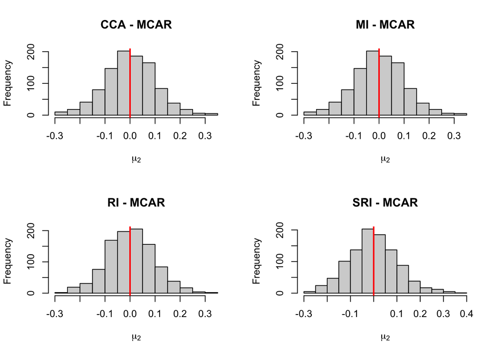

```r
par(mfrow = c(2,2))
hist(res_CCA_MCAR$mu2ests, xlab = expression(mu[2]), main = "CCA - MCAR")
abline(v = mu2, col = "red", lwd = 2)

hist(res_MI_MCAR$mu2ests, xlab = expression(mu[2]), main = "MI - MCAR")
abline(v = mu2, col = "red", lwd = 2)

hist(res_RI_MCAR$mu2ests, xlab = expression(mu[2]), main = "RI - MCAR")
abline(v = mu2, col = "red", lwd = 2)

hist(res_SRI_MCAR$mu2ests, xlab = expression(mu[2]), main = "SRI - MCAR")
abline(v = mu2, col = "red", lwd = 2)
```

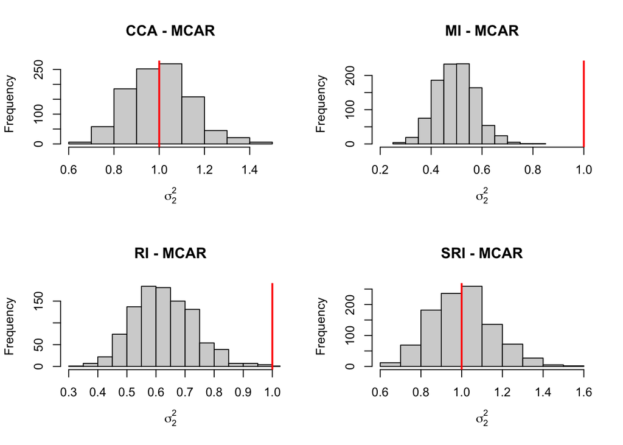

```r
par(mfrow = c(2,2))
hist(res_CCA_MCAR$var2ests, xlab = expression(sigma[2]^2), main = "CCA - MCAR")
abline(v = sigma22, col = "red", lwd = 2)

hist(res_MI_MCAR$var2ests, xlab = expression(sigma[2]^2), main = "MI - MCAR",
      xlim = c(0.2, 1))
abline(v = sigma22, col = "red", lwd = 2)

hist(res_RI_MCAR$var2ests, xlab = expression(sigma[2]^2), main = "RI - MCAR",
     xlim = c(0.3, 1))
abline(v = sigma22, col = "red", lwd = 2)

hist(res_SRI_MCAR$var2ests, xlab = expression(sigma[2]^2), main = "SRI - MCAR")
abline(v = sigma22, col = "red", lwd = 2)
```

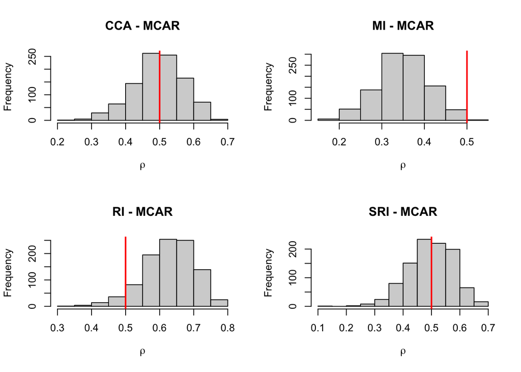

```r
par(mfrow = c(2,2))
hist(res_CCA_MCAR$corrests, xlab = expression(rho), main = "CCA - MCAR")
abline(v = rho, col = "red", lwd = 2)

hist(res_MI_MCAR$corrests, xlab = expression(rho), main = "MI - MCAR")
abline(v = rho, col = "red", lwd = 2)

hist(res_RI_MCAR$corrests, xlab = expression(rho), main = "RI - MCAR")
abline(v = rho, col = "red", lwd = 2)

hist(res_SRI_MCAR$corrests, xlab = expression(rho), main = "SRI - MCAR")
abline(v = rho, col = "red", lwd = 2)
```

```r
#estimates for the complete data
mu2est_complete_data <- apply(y2, 2, mean)
var2est_complete_data <- apply(y2, 2, var)
ll_complete_data <- ul_complete_data <- numeric(nsim)
for(l in 1:nsim){
   ll_complete_data[l] <- mu2est_complete_data[l] -
     qt(0.975, n-1)*sqrt(var2est_complete_data[l]/n)
   ul_complete_data[l] <- mu2est_complete_data[l] +
     qt(0.975, n-1)*sqrt(var2est_complete_data[l]/n)
}
width_complete_data <- ul_complete_data - ll_complete_data

width_CCA <- res_CCA_MCAR$uls - res_CCA_MCAR$lls

mean(width_complete_data)
```

```
## [1] 0.2788024
```

```r
mean(width_CCA)
```

```
## [1] 0.3968747
```

Let us now move to the MAR data case. We will impose the missingness as instructed before and we will then pass this to the function we have created and produce the results for the four methods.

```r
beta0 <- 1.5; beta1 <- 3
r <- matrix(0, nrow = n, ncol = nsim)
for(l in 1:nsim){
  r[, l] <- rbinom(n, 1, exp(beta0+beta1*y1[,l])/(1+exp(beta0+beta1*y1[,l])))
}

res_CCA_MAR <- single_imp_sim(y1 = y1, y2 = y2, r = r, method = "CCA")
mu2_CCA_MAR <- mean(res_CCA_MAR$mu2ests)
sigma22_CCA_MAR <- mean(res_CCA_MAR$var2ests)
rho_CCA_MAR <- mean(res_CCA_MAR$corrests)
coverage_CCA_MAR <- sum((res_CCA_MAR$lls <= mu2) & (res_CCA_MAR$uls >= mu2))/nsim

res_MI_MAR <- single_imp_sim(y1 = y1, y2 = y2, r = r, method = "MI")
mu2_MI_MAR <- mean(res_MI_MAR$mu2ests)
sigma22_MI_MAR <- mean(res_MI_MAR$var2ests)
rho_MI_MAR <- mean(res_MI_MAR$corrests)
coverage_MI_MAR <- sum((res_MI_MAR$lls <= mu2) & (res_MI_MAR$uls >= mu2))/nsim

res_RI_MAR <- single_imp_sim(y1 = y1, y2 = y2, r = r, method = "RI")
mu2_RI_MAR <- mean(res_RI_MAR$mu2ests)
sigma22_RI_MAR <- mean(res_RI_MAR$var2ests)
rho_RI_MAR <- mean(res_RI_MAR$corrests)
coverage_RI_MAR <- sum((res_RI_MAR$lls <= mu2) & (res_RI_MAR$uls >= mu2))/nsim

res_SRI_MAR <- single_imp_sim(y1 = y1, y2 = y2, r = r, method = "SRI")
mu2_SRI_MAR <- mean(res_SRI_MAR$mu2ests)
sigma22_SRI_MAR <- mean(res_SRI_MAR$var2ests)
rho_SRI_MAR <- mean(res_SRI_MAR$corrests)
coverage_SRI_MAR <- sum((res_SRI_MAR$lls <= mu2) & (res_SRI_MAR$uls >= mu2))/nsim

df <- data.frame("Mu2" = c(mu2_CCA_MAR, mu2_MI_MAR, mu2_RI_MAR, mu2_SRI_MAR),
                 "Sigma22" = c(sigma22_CCA_MAR, sigma22_MI_MAR,
                               sigma22_RI_MAR, sigma22_SRI_MAR),
                 "Rho" = c(rho_CCA_MAR, rho_MI_MAR,
                           rho_RI_MAR, rho_SRI_MAR),
                 "Cov" = c(coverage_CCA_MAR,coverage_MI_MAR,coverage_RI_MAR,
                           coverage_SRI_MAR))
rownames(df) <- c("CCA", "MI", "RI", "SRI")
colnames(df) = c("$\\mu_2$", "$\\sigma_2^2$", "$\\rho$", "Coverage")

knitr::kable(df, escape = FALSE, digits = 4, caption = "MAR data")
```

MAR data

|  | $\mu_2$ | $\sigma_2^2$ | $\rho$ | Coverage |
| --- | --- | --- | --- | --- |
| CCA | 0.2352 | 0.9000 | 0.4060 | 0.183 |
| MI | 0.2352 | 0.5984 | 0.2569 | 0.062 |
| RI | 0.0007 | 0.7539 | 0.5715 | 0.791 |
| SRI | 0.0025 | 1.0042 | 0.4935 | 0.818 |

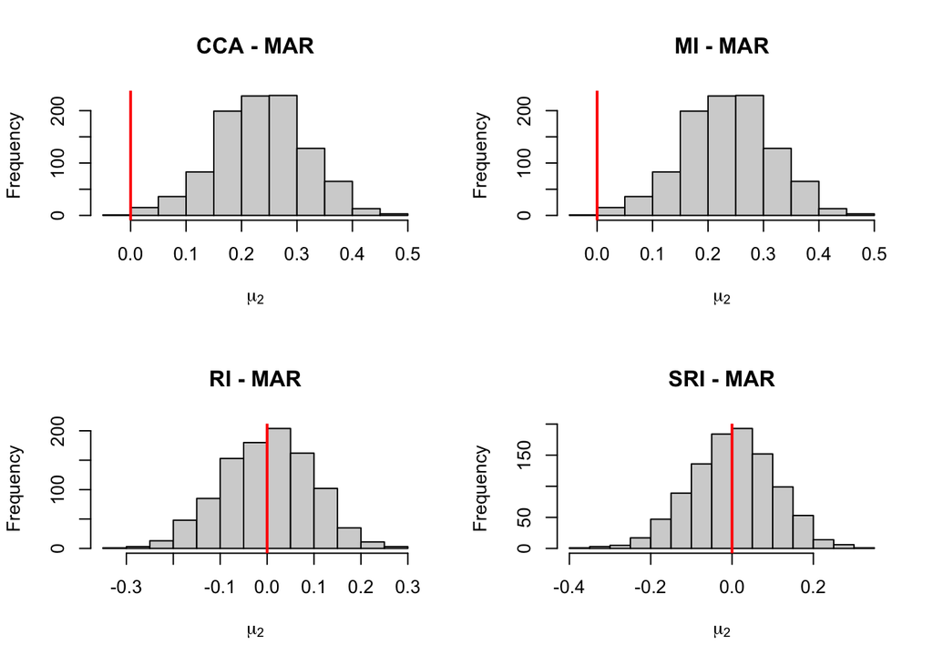

```r
par(mfrow = c(2,2))
hist(res_CCA_MAR$mu2ests, xlab = expression(mu[2]), main = "CCA - MAR")
abline(v = mu2, col = "red", lwd = 2)

hist(res_MI_MAR$mu2ests, xlab = expression(mu[2]), main = "MI - MAR")
abline(v = mu2, col = "red", lwd = 2)

hist(res_RI_MAR$mu2ests, xlab = expression(mu[2]), main = "RI - MAR")
abline(v = mu2, col = "red", lwd = 2)

hist(res_SRI_MAR$mu2ests, xlab = expression(mu[2]), main = "SRI - MAR")
abline(v = mu2, col = "red", lwd = 2)
```

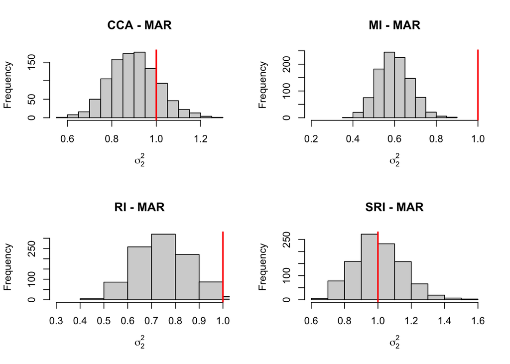

```r
par(mfrow = c(2,2))
hist(res_CCA_MAR$var2ests, xlab = expression(sigma[2]^2), main = "CCA - MAR")
abline(v = sigma22, col = "red", lwd = 2)

hist(res_MI_MAR$var2ests, xlab = expression(sigma[2]^2), main = "MI - MAR",
      xlim = c(0.2, 1))
abline(v = sigma22, col = "red", lwd = 2)

hist(res_RI_MAR$var2ests, xlab = expression(sigma[2]^2), main = "RI - MAR",
     xlim = c(0.3, 1))
abline(v = sigma22, col = "red", lwd = 2)

hist(res_SRI_MAR$var2ests, xlab = expression(sigma[2]^2), main = "SRI - MAR")
abline(v = sigma22, col = "red", lwd = 2)
```

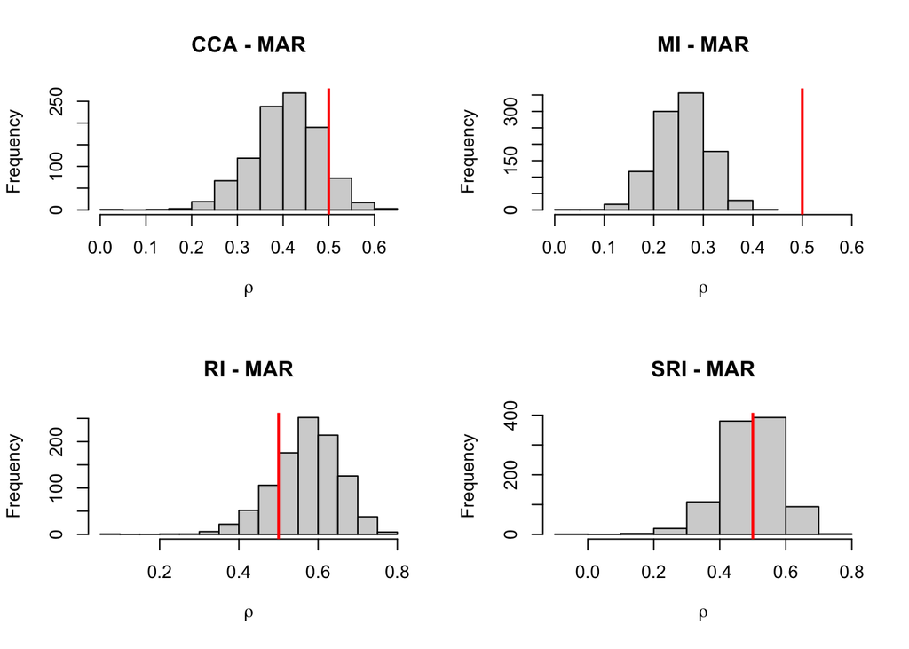

```r
par(mfrow = c(2,2))
hist(res_CCA_MAR$corrests, xlab = expression(rho), main = "CCA - MAR")
abline(v = rho, col = "red", lwd = 2)

hist(res_MI_MAR$corrests, xlab = expression(rho), main = "MI - MAR",
     xlim = c(0, 0.6))
abline(v = rho, col = "red", lwd = 2)

hist(res_RI_MAR$corrests, xlab = expression(rho), main = "RI - MAR")
abline(v = rho, col = "red", lwd = 2)

hist(res_SRI_MAR$corrests, xlab = expression(rho), main = "SRI - MAR")
abline(v = rho, col = "red", lwd = 2)
```

For this scenario (MAR data), only stochastic regression imputation manages to provide accurate estimates of the mean, variance, and correlation although, as expected, the coverage is still quite below the nominal level ($0.95$).

Lastly, let us see what happens with missingness imposed under a MNAR mechanism.

```r
beta0 <- 1.5; beta1 <- 3; beta2 <- 5
r <- matrix(0, nrow = n, ncol = nsim)
for(i in 1:nsim){
  r[, i] <- rbinom(n, 1, exp(beta0+beta1*y1[,i]+beta2*y2[,i])/(1+exp(beta0+beta1*y1[,i]+beta2*y2[,i])))
}

res_CCA_MNAR <- single_imp_sim(y1 = y1, y2 = y2, r = r, method = "CCA")
mu2_CCA_MNAR <- mean(res_CCA_MNAR$mu2ests)
sigma22_CCA_MNAR <- mean(res_CCA_MNAR$var2ests)
rho_CCA_MNAR <- mean(res_CCA_MNAR$corrests)
coverage_CCA_MNAR <- sum((res_CCA_MNAR$lls <= mu2) & (res_CCA_MNAR$uls >= mu2))/nsim

res_MI_MNAR <- single_imp_sim(y1 = y1, y2 = y2, r = r, method = "MI")
mu2_MI_MNAR <- mean(res_MI_MNAR$mu2ests)
sigma22_MI_MNAR <- mean(res_MI_MNAR$var2ests)
rho_MI_MNAR <- mean(res_MI_MNAR$corrests)
coverage_MI_MNAR <- sum((res_MI_MNAR$lls <= mu2) & (res_MI_MNAR$uls >= mu2))/nsim

res_RI_MNAR <- single_imp_sim(y1 = y1, y2 = y2, r = r, method = "RI")
mu2_RI_MNAR <- mean(res_RI_MNAR$mu2ests)
sigma22_RI_MNAR <- mean(res_RI_MNAR$var2ests)
rho_RI_MNAR <- mean(res_RI_MNAR$corrests)
coverage_RI_MNAR <- sum((res_RI_MNAR$lls <= mu2) & (res_RI_MNAR$uls >= mu2))/nsim

res_SRI_MNAR <- single_imp_sim(y1 = y1, y2 = y2, r = r, method = "SRI")
mu2_SRI_MNAR <- mean(res_SRI_MNAR$mu2ests)
sigma22_SRI_MNAR <- mean(res_SRI_MNAR$var2ests)
rho_SRI_MNAR <- mean(res_SRI_MNAR$corrests)
coverage_SRI_MNAR <- sum((res_SRI_MNAR$lls <= mu2) & (res_SRI_MNAR$uls >= mu2))/nsim

df <- data.frame("Mu2" = c(mu2_CCA_MNAR, mu2_MI_MNAR, mu2_RI_MNAR, mu2_SRI_MNAR),
                 "Sigma22" = c(sigma22_CCA_MNAR, sigma22_MI_MNAR,
                               sigma22_RI_MNAR, sigma22_SRI_MNAR),
                 "Rho" = c(rho_CCA_MNAR, rho_MI_MNAR,
                           rho_RI_MNAR, rho_SRI_MNAR),
                 "Cov" = c(coverage_CCA_MNAR,coverage_MI_MNAR,coverage_RI_MNAR,
                           coverage_SRI_MNAR))
rownames(df) <- c("CCA", "MI", "RI", "SRI")
colnames(df) = c("$\\mu_2$", "$\\sigma_2^2$", "$\\rho$", "Coverage")

knitr::kable(df, escape = FALSE, digits = 4, caption = "MNAR data")
```

MNAR data

|  | $\mu_2$ | $\sigma_2^2$ | $\rho$ | Coverage |
| --- | --- | --- | --- | --- |
| CCA | 0.6030 | 0.5212 | 0.1626 | 0 |
| MI | 0.6030 | 0.3025 | 0.1006 | 0 |
| RI | 0.5286 | 0.3204 | 0.2531 | 0 |
| SRI | 0.5289 | 0.5337 | 0.1963 | 0 |

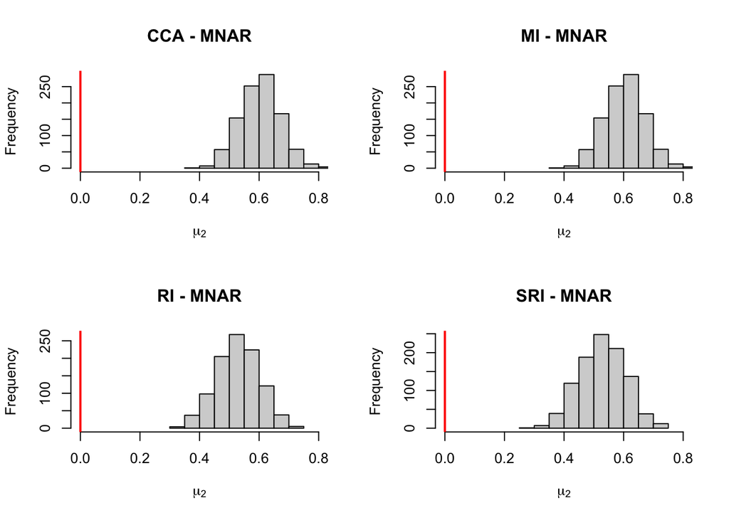

```r
par(mfrow = c(2,2))
hist(res_CCA_MNAR$mu2ests, xlab = expression(mu[2]), main = "CCA - MNAR",
     xlim = c(0,0.8))
abline(v = mu2, col = "red", lwd = 2)

hist(res_MI_MNAR$mu2ests, xlab = expression(mu[2]), main = "MI - MNAR",
     xlim = c(0,0.8))
abline(v = mu2, col = "red", lwd = 2)

hist(res_RI_MNAR$mu2ests, xlab = expression(mu[2]), main = "RI - MNAR",
     xlim = c(0,0.8))
abline(v = mu2, col = "red", lwd = 2)

hist(res_SRI_MNAR$mu2ests, xlab = expression(mu[2]), main = "SRI - MNAR",
     xlim = c(0,0.8))
abline(v = mu2, col = "red", lwd = 2)
```

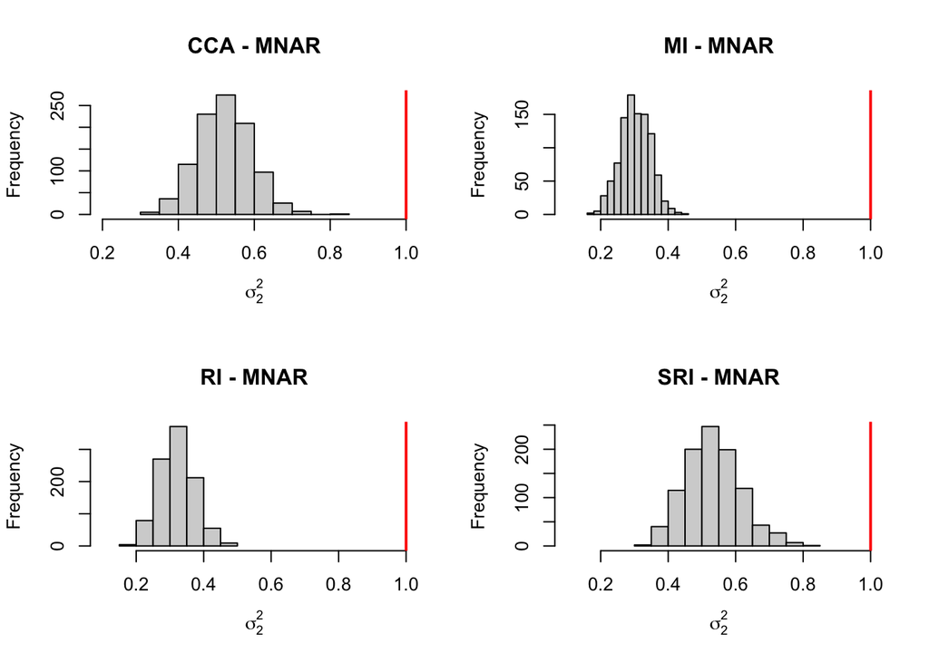

```r
par(mfrow = c(2,2))
hist(res_CCA_MNAR$var2ests, xlab = expression(sigma[2]^2), main = "CCA - MNAR",
     xlim = c(0.2, 1))
abline(v = sigma22, col = "red", lwd = 2)

hist(res_MI_MNAR$var2ests, xlab = expression(sigma[2]^2), main = "MI - MNAR",
      xlim = c(0.1, 1))
abline(v = sigma22, col = "red", lwd = 2)

hist(res_RI_MNAR$var2ests, xlab = expression(sigma[2]^2), main = "RI - MNAR",
     xlim = c(0.1, 1))
abline(v = sigma22, col = "red", lwd = 2)

hist(res_SRI_MNAR$var2ests, xlab = expression(sigma[2]^2), main = "SRI - MNAR",
     xlim = c(0.1, 1))
abline(v = sigma22, col = "red", lwd = 2)
```

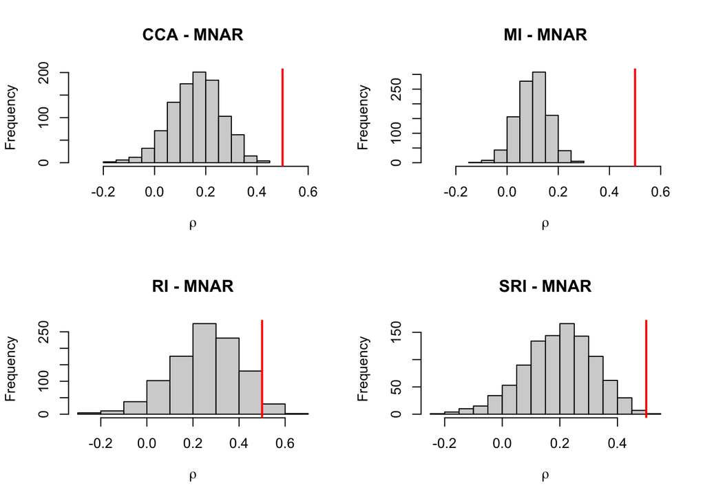

```r
par(mfrow = c(2,2))
hist(res_CCA_MNAR$corrests, xlab = expression(rho), main = "CCA - MNAR",
     xlim = c(-0.3, 0.6))
abline(v = rho, col = "red", lwd = 2)

hist(res_MI_MNAR$corrests, xlab = expression(rho), main = "MI - MNAR",
     xlim = c(-0.3, 0.6))
abline(v = rho, col = "red", lwd = 2)

hist(res_RI_MNAR$corrests, xlab = expression(rho), main = "RI - MNAR")
abline(v = rho, col = "red", lwd = 2)

hist(res_SRI_MNAR$corrests, xlab = expression(rho), main = "SRI - MNAR")
abline(v = rho, col = "red", lwd = 2)
```

As we can see, under MNAR, all methods provide biased results of all quantities. MNAR data are hard to handle!

As a final note I remark that the way to deal with missing data depends on the final aim. If the aim is to do inference, estimating parameters and their variances as well as possible, then single imputation is clearly inadequate.